# Electroencephalography Markers of Perinatal Depression and Anxiety in a Diverse Longitudinal Cohort: A Preliminary Study

This repository contains the R scripts utilized to analyze the data reported in Attre, Maigh S., Suzanne A. Alvernaz, Elizabeth Wenzel, Abigail Pettineo, Sarah Parikh, Catherine Conway, Molly Kroeger et al. “Electroencephalography Markers of Perinatal Depression and Anxiety in a Diverse Longitudinal Cohort: A Preliminary Study.” medRxiv (2024): 2024-10.

In this study, pregnant participants were recruited from the University of Illinois Hospital & Health Sciences System as part of the MoMent Study (Moms and Mental Health). Participants completed a resting state portable EEG recording, and self-reported mental health surveys (PHQ-9 and GAD-7). The script for analyzing the PHQ-9 and GAD-7 changes related to brain functionality can be found in the Scripts folder. For questions about this repository, please email bealabgithub@gmail.com. Data is available upon request and IRB approval, please email penalver@uic.edu

## Data Collection

Portable EEG and mental health scores were collected at five timepoints across pregnancy

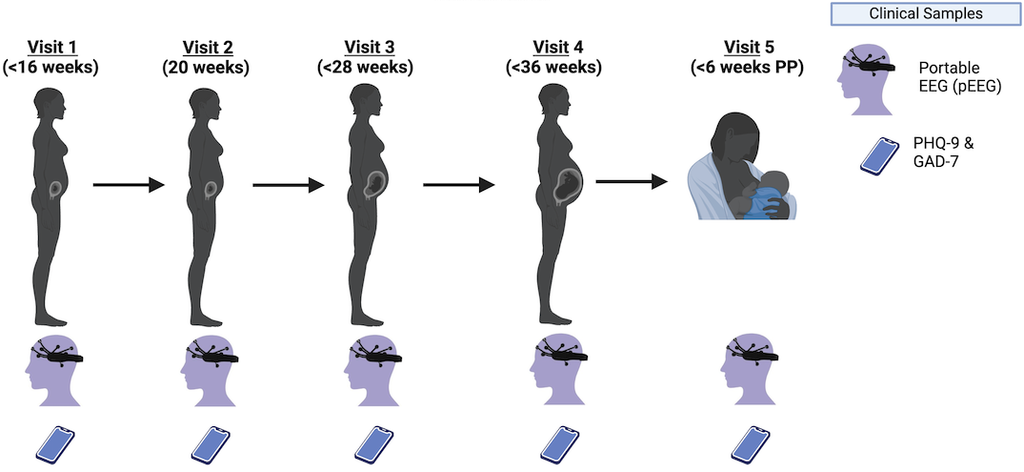

## Findings

A summary of the findings are outlined below

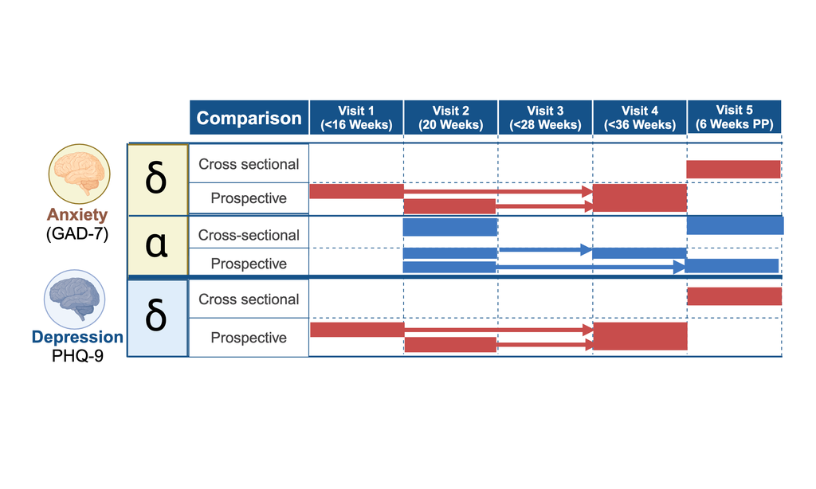